# Project: Investigating a Soccer Dataset

- Introduction
- SQL Code
- Data Wrangling
- Exploratory Data Analysis
- Conclusions

## Introduction

> I have selected to use the [European Soccer Dataset](https://www.kaggle.com/hugomathien/soccer) from Kaggle which includes the results to European league match games from 2008 to 2016.

> I plan to explore:  
> 1) What leagues have the greatest home field advantage in regards to home goal differential?  
> 2) What leagues have the greatest home field advantage in regards to home point differential?  
> 3) Do the leagues with the highest home goal differential also have the highest home point differential? How well are those correlated?  
> 4) Does the amount of goals scored in a game on average impact home team's point differential or goal differential?

## SQL Code

> This is the code that was used in SQL to export the CSV I will import and use in this project.

> SELECT League.name League_Name, Match.Home_Team_Goal Home_Team_Goal, Match.Away_Team_Goal Away_Team_Goal  
> FROM League  
> JOIN Match  
> ON League.id = Match.league_id

```python
import numpy as np
import pandas as pd
import matplotlib.pyplot as plt
%matplotlib inline
```

## Data Wrangling

> Most of the data wrangling took place in my SQL query and only extracting the code I needed from there.

### General Properties

```python
df = pd.read_csv('/Users/markverso/Documents/Python/Soccer DataSet Python.csv')
df.head()
```

|  | League_Name | Home_Team_Goal | Away_Team_Goal |
| --- | --- | --- | --- |
| 0 | Belgium Jupiler League | 1 | 1 |
| 1 | Belgium Jupiler League | 0 | 0 |
| 2 | Belgium Jupiler League | 0 | 3 |
| 3 | Belgium Jupiler League | 5 | 0 |
| 4 | Belgium Jupiler League | 1 | 3 |

### Data Cleaning

> The data is clean. All rows do not have null values and are in the format they are required to be in for analysis.

```python
df.info()
```

```
<class 'pandas.core.frame.DataFrame'>
RangeIndex: 25979 entries, 0 to 25978
Data columns (total 3 columns):
 #   Column          Non-Null Count  Dtype
---  ------          --------------  -----
 0   League_Name     25979 non-null  object
 1   Home_Team_Goal  25979 non-null  int64
 2   Away_Team_Goal  25979 non-null  int64
dtypes: int64(2), object(1)
memory usage: 609.0+ KB
```

## Exploratory Data Analysis

### What leagues have the greatest home Goal Differential Advantage?

> To figure this out, I want to get the goal differential for each game.

```python
df['Home_Goal_Differential'] = df['Home_Team_Goal'] - df['Away_Team_Goal']
df['Home_Goal_Differential']
```

```
0        0
1        0
2       -3
3        5
4       -2
        ..
25974    1
25975   -1
25976    2
25977    0
25978    1
Name: Home_Goal_Differential, Length: 25979, dtype: int64
```

> The average goal differential for European leagues is .38 goals as seen below.

```python
df.describe()
```

|  | Home_Team_Goal | Away_Team_Goal | Home_Goal_Differential |
| --- | --- | --- | --- |
| count | 25979.000000 | 25979.000000 | 25979.000000 |
| mean | 1.544594 | 1.160938 | 0.383656 |
| std | 1.297158 | 1.142110 | 1.782403 |
| min | 0.000000 | 0.000000 | -9.000000 |
| 25% | 1.000000 | 0.000000 | -1.000000 |
| 50% | 1.000000 | 1.000000 | 0.000000 |
| 75% | 2.000000 | 2.000000 | 1.000000 |
| max | 10.000000 | 9.000000 | 10.000000 |

```python
home_goal_avg = df['Home_Team_Goal'].mean()
away_goal_avg = df['Away_Team_Goal'].mean()
home_goal_diff = df['Home_Goal_Differential'].mean()
home_goal_avg, away_goal_avg, home_goal_diff
```

```
(1.5445937103044767, 1.1609376804341969, 0.38365602987027986)
```

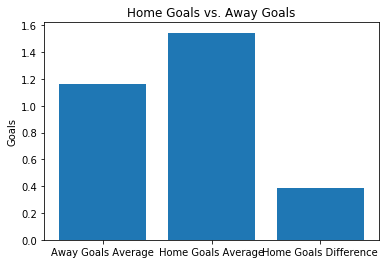

```python
plt.bar(["Away Goals Average", "Home Goals Average", "Home Goals Difference"], [away_goal_avg, home_goal_avg, home_goal_diff])
plt.title("Home Goals vs. Away Goals")
plt.ylabel("Goals");
```

> Below I look at how many goals are typically scored in a game by the home and away teams. This is helpful because below you see that in over 2/3's of games, away teams score 0 or 1 goals while the home generates 2 or more goals in a close to 45% of all games. Furthermore, the rarity of 3+ goal games indicates that most games are decided by a goal or less which is shown on third histogram below. This indicates that most goals are crucial to a games outcome and a partial goal advantage on average would mean a significant difference in points gained.

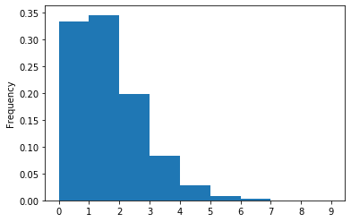

```python
df["Away_Team_Goal"].plot.hist(weights = np.ones_like(df.index) / len(df.index),
                               bins = max(df["Away_Team_Goal"]) - min(df["Away_Team_Goal"]),
                               xticks = df["Away_Team_Goal"].unique().tolist());
```

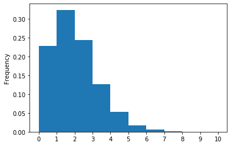

```python
df["Home_Team_Goal"].plot.hist(weights = np.ones_like(df.index) / len(df.index),
                               bins = max(df["Home_Team_Goal"]) - min(df["Home_Team_Goal"]),
                               xticks = df["Home_Team_Goal"].unique().tolist());
```

```python
xtick = df["Home_Goal_Differential"].unique().tolist()
print(xtick)
```

```
[0, -3, 5, -2, -1, 1, 3, 2, 4, -4, -6, 6, -5, 7, 8, -9, -7, 10, 9, -8]
```

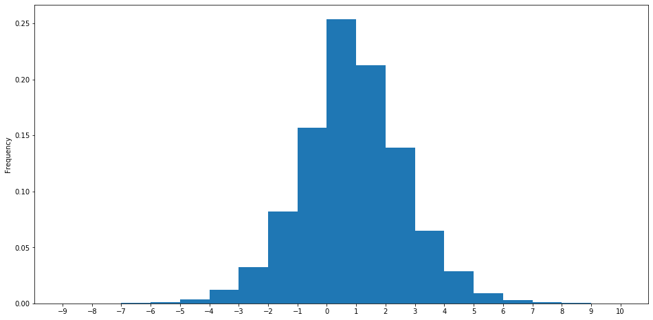

```python
df["Home_Goal_Differential"].plot.hist(weights = np.ones_like(df.index) / len(df.index),
                                       bins = max(df["Home_Goal_Differential"]) - min(df["Home_Goal_Differential"]),
                                       xticks = df["Home_Goal_Differential"].unique().tolist(),
                                       figsize = (16,8));
```

> Below is a sorted list of European soccer leagues.

```python
League_Home_Goal_Differential = df.groupby('League_Name')['Home_Goal_Differential'].mean().nlargest(len('League_Name'))
League_Home_Goal_Differential
```

```
League_Name
Spain LIGA BBVA             0.495395
Netherlands Eredivisie      0.478758
Belgium Jupiler League      0.417245
Switzerland Super League    0.396624
England Premier League      0.391447
Italy Serie A               0.384819
Poland Ekstraklasa          0.364583
France Ligue 1              0.362829
Germany 1. Bundesliga       0.351716
Portugal Liga ZON Sagres    0.282164
Scotland Premier League     0.224781
Name: Home_Goal_Differential, dtype: float64
```

### What leagues have the greatest Home Point Differential Advantage?

> To understand the league home point differential, you take the home average points minus the away points. The reason why you do this instead of just taking the home point average is that a league that contains all ties would equate to each team getting 1 point per game while a league that has 0 ties would give teams an average of 1.5 points per game (3 to the victor, 0 to the loser). So, home victories matter more in league with more ties.

```python
df['Home_Points'] = df['Home_Goal_Differential'].apply(lambda x: 3 if x > 0 else (1 if x == 0 else 0))
df['Home_Points'].mean()
```

```
1.6300473459332538
```

```python
df['Away_Points'] = df['Home_Goal_Differential'].apply(lambda x: 3 if x < 0 else (1 if x == 0 else 0))
df['Away_Points'].mean()
```

```
1.1160552754147581
```

```python
df['Home_Point_Differential'] = df['Home_Points'] - df['Away_Points']
df['Home_Point_Differential'].mean()
```

```
0.5139920705184957
```

```python
League_Home_Point_Differential = df.groupby('League_Name')['Home_Point_Differential'].mean().nlargest(len('League_Name'))
League_Home_Point_Differential
```

```
League_Name
Spain LIGA BBVA             0.625658
Italy Serie A               0.589659
Netherlands Eredivisie      0.582108
Belgium Jupiler League      0.550347
Poland Ekstraklasa          0.539062
France Ligue 1              0.529934
England Premier League      0.516118
Switzerland Super League    0.472574
Germany 1. Bundesliga       0.444853
Portugal Liga ZON Sagres    0.434211
Scotland Premier League     0.235197
Name: Home_Point_Differential, dtype: float64
```

### Does a game that includes additional goals for the home team lead to more points for the home team as well?

> To understand the correlation I plotted the Home Point Differential and Home Goal Differential on a scatter plot. In order to do this, I have to make both data points part of the same data frame.

> I compare the home point differential and home goal differential by making them data frames, which enables me to join them together based on their league names. I use that data to make a plot below.

```python
League_Home_Point_Differential = League_Home_Point_Differential.to_frame()
```

```python
League_Home_Goal_Differential = League_Home_Goal_Differential.to_frame()
```

```python
results = League_Home_Point_Differential.merge(League_Home_Goal_Differential, on = 'League_Name')
results
```

| League_Name | Home_Point_Differential | Home_Goal_Differential |
| --- | --- | --- |
| Spain LIGA BBVA | 0.625658 | 0.495395 |
| Italy Serie A | 0.589659 | 0.384819 |
| Netherlands Eredivisie | 0.582108 | 0.478758 |
| Belgium Jupiler League | 0.550347 | 0.417245 |
| Poland Ekstraklasa | 0.539062 | 0.364583 |
| France Ligue 1 | 0.529934 | 0.362829 |
| England Premier League | 0.516118 | 0.391447 |
| Switzerland Super League | 0.472574 | 0.396624 |
| Germany 1. Bundesliga | 0.444853 | 0.351716 |
| Portugal Liga ZON Sagres | 0.434211 | 0.282164 |
| Scotland Premier League | 0.235197 | 0.224781 |

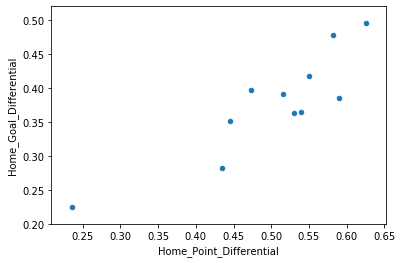

```python
results.plot(x = 'Home_Point_Differential', y = 'Home_Goal_Differential', kind = 'scatter');
```

### Does the amount of goals scored in a game impact goal differentials and/or point differentials?

> To understand this I would want to investiage how many goals are scored on average in each league. Italy is known as being a defensive league and goals matter more when they are scored.

> I investigate this by adding the average home and away goals from each league together and adding them to the result data frame.

```python
df['Total_League_Goals'] = df['Home_Team_Goal'] + df['Away_Team_Goal']
League_Average_Goals = df.groupby('League_Name')['Total_League_Goals'].mean().nlargest(len('League_Name'))
League_Average_Goals = League_Average_Goals.to_frame()
results = results.merge(League_Average_Goals, on = 'League_Name')
results
```

| League_Name | Home_Point_Differential | Home_Goal_Differential | Total_League_Goals |
| --- | --- | --- | --- |
| Spain LIGA BBVA | 0.625658 | 0.495395 | 2.767105 |
| Italy Serie A | 0.589659 | 0.384819 | 2.616838 |
| Netherlands Eredivisie | 0.582108 | 0.478758 | 3.080882 |
| Belgium Jupiler League | 0.550347 | 0.417245 | 2.801505 |
| Poland Ekstraklasa | 0.539062 | 0.364583 | 2.425000 |
| France Ligue 1 | 0.529934 | 0.362829 | 2.443092 |
| England Premier League | 0.516118 | 0.391447 | 2.710526 |
| Switzerland Super League | 0.472574 | 0.396624 | 2.929677 |
| Germany 1. Bundesliga | 0.444853 | 0.351716 | 2.901552 |
| Portugal Liga ZON Sagres | 0.434211 | 0.282164 | 2.534600 |
| Scotland Premier League | 0.235197 | 0.224781 | 2.633772 |

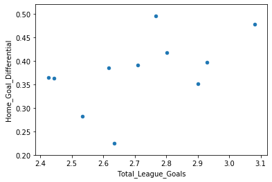

```python
results.plot(x = 'Total_League_Goals', y = 'Home_Goal_Differential', kind = 'scatter');
```

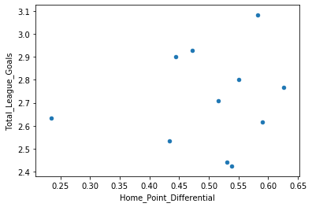

```python
results.plot(x = 'Home_Point_Differential', y = 'Total_League_Goals', kind = 'scatter');
```

## Conclusions

> The Spanish league has the greatest home differential in terms of points and goals while the Scottish league has the lowest in both categories. Goal differentials are highly correlated with point differentials, but there are a few notable deviations from the norm. For example, the Italian league has a much higher home point differential relative to its home goal differential than other leagues. I investigated to see whether the average amount of goals score in a game would impact the home goal differential or the home point differential, but it showed no correlation with either.